# HW2 - EDA with R - Part 1: Statistics and Plotting

Osarodion

January 9, 2022

## Step 1 - Familiarize yourself with the data and the assignment

In this assignment you’ll do some exploratory data analysis with R on a dataset of housing prices. The version of this data that we’ll be using is based on a Kaggle dataset - https://www.kaggle.com/harlfoxem/housesalesprediction. I’ve made some changes and you can find a data dictionary in the same folder as this file.

As we did in the R related sessions, you’ll be editing an R Markdown document to do some analysis as well as to document the steps you did (and answer some questions I’ll throw at you).

You’ll notice a few “Hacker Extra Credit” tasks thrown in. These are for those of you who want to go a little above and beyond and attempt some more challenging tasks. And, feel free to do a some free form Hacker Extra style work yourself - in other words, do something beyond what was asked. You’ll learn more.

## Step 2 - Create a new R Markdown document based on this document

Save this file as a new R Markdown document and name it **hw2_eda_part1_[your last name].Rmd**. Mine would be called **hw2_eda_part1_isken.Rmd**. Save it into the same folder as this file.

This will be your working directory.

Create a new R Project based on this working directory.

## Step 3 - Explore data folder

Inside of the main project folder you’ll find the data files for this assignment in a subfolder called `data/`.

- **kc_house_data_original.csv**
- **kc_house_data.Rdata**

The first file is from the Kaggle site for this dataset. I made some changes and created the Rdata file which contains the dataframe that you’ll be using for your analysis.

You might want to use shell commands or a text editor like Geany to snoop the csv file a bit.

## Step 4 - Complete the following R tasks and answer questions

Now you’ll need to complete the following tasks in R. Just like we did in class, you should use a combination of markdown text (be concise, no need to write tons of text) to explain what you are doing and R code chunks to actually do it. When you are done, use the “Knit” button to generate an HTML file from your R Markdown.

Note that if you have errors in your R code, **knitr** will stop at the error and won’t create an html file. Sooo, you should comment out R code that has errors and write a little comment stating that it’s an error and a possible explanation for the error. Of course, try to fix the errors. Keep doing this until you successfully knit an html file based on your R Markdown document. You’ll be submitting both the html file as well as the Rmd file.

You’ll notice that I’ve left some empty code chunks as well as some partially filled in code chunks. Of course, feel free to add more code chunks as needed.

Let’s load a few libraries we’ll need:

```r
library(dplyr)
```

```r
library(ggplot2)
```

### Problem 1 - Load the Rdata file

Let’s load the data from the Rdata file.

```r
load("data/kc_house_data.Rdata")
```

Check the structure of the data.frame using `str` and use the `summary` function to begin exploring the data.

```r
str(kc_house_data)
```

```
## 'data.frame':    21613 obs. of  23 variables:
##  $ id           : num  7.13e+09 6.41e+09 5.63e+09 2.49e+09 1.95e+09 ...
##  $ date         : chr  "20141013T000000" "20141209T000000" "20150225T000000" "20141209T000000" ...
##  $ price        : num  221900 538000 180000 604000 510000 ...
##  $ bedrooms     : int  3 3 2 4 3 4 3 3 3 3 ...
##  $ bathrooms    : num  1 2.25 1 3 2 4.5 2.25 1.5 1 2.5 ...
##  $ sqft_living  : int  1180 2570 770 1960 1680 5420 1715 1060 1780 1890 ...
##  $ sqft_lot     : int  5650 7242 10000 5000 8080 101930 6819 9711 7470 6560 ...
##  $ floors       : num  1 2 1 1 1 1 2 1 1 2 ...
##  $ waterfront   : Factor w/ 2 levels "0","1": 1 1 1 1 1 1 1 1 1 1 ...
##  $ view         : Factor w/ 5 levels "0","1","2","3",..: 1 1 1 1 1 1 1 1 1 1 ...
##  $ condition    : Factor w/ 5 levels "1","2","3","4",..: 3 3 3 5 3 3 3 3 3 3 ...
##  $ grade        : Factor w/ 12 levels "1","3","4","5",..: 6 6 5 6 7 10 6 6 6 6 ...
##  $ sqft_above   : int  1180 2170 770 1050 1680 3890 1715 1060 1050 1890 ...
##  $ sqft_basement: int  0 400 0 910 0 1530 0 0 730 0 ...
##  $ yr_built     : int  1955 1951 1933 1965 1987 2001 1995 1963 1960 2003 ...
##  $ yr_renovated : int  0 1991 0 0 0 0 0 0 0 0 ...
##  $ zipcode      : Factor w/ 70 levels "98001","98002",..: 67 56 17 59 38 30 3 69 61 24 ...
##  $ lat          : num  47.5 47.7 47.7 47.5 47.6 ...
##  $ long         : num  -122 -122 -122 -122 -122 ...
##  $ sqft_living15: int  1340 1690 2720 1360 1800 4760 2238 1650 1780 2390 ...
##  $ sqft_lot15   : int  5650 7639 8062 5000 7503 101930 6819 9711 8113 7570 ...
##  $ age          : num  60 64 82 50 28 14 20 52 55 12 ...
##  $ reno_age     : num  60 24 82 50 28 14 20 52 55 12 ...
```

```r
summary(kc_house_data)
```

```
##        id                date               price            bedrooms
##  Min.   :1.000e+06   Length:21613       Min.   :  75000   Min.   : 0.000
##  1st Qu.:2.123e+09   Class :character   1st Qu.: 321950   1st Qu.: 3.000
##  Median :3.905e+09   Mode  :character   Median : 450000   Median : 3.000
##  Mean   :4.580e+09                      Mean   : 540088   Mean   : 3.371
##  3rd Qu.:7.309e+09                      3rd Qu.: 645000   3rd Qu.: 4.000
##  Max.   :9.900e+09                      Max.   :7700000   Max.   :33.000
##
##    bathrooms      sqft_living       sqft_lot           floors      waterfront
##  Min.   :0.000   Min.   :  290   Min.   :    520   Min.   :1.000   0:21450
##  1st Qu.:1.750   1st Qu.: 1427   1st Qu.:   5040   1st Qu.:1.000   1:  163
##  Median :2.250   Median : 1910   Median :   7618   Median :1.500
##  Mean   :2.115   Mean   : 2080   Mean   :  15107   Mean   :1.494
##  3rd Qu.:2.500   3rd Qu.: 2550   3rd Qu.:  10688   3rd Qu.:2.000
##  Max.   :8.000   Max.   :13540   Max.   :1651359   Max.   :3.500
##
##  view      condition     grade        sqft_above   sqft_basement
##  0:19489   1:   30   7      :8981   Min.   : 290   Min.   :   0.0
##  1:  332   2:  172   8      :6068   1st Qu.:1190   1st Qu.:   0.0
##  2:  963   3:14031   9      :2615   Median :1560   Median :   0.0
##  3:  510   4: 5679   6      :2038   Mean   :1788   Mean   : 291.5
##  4:  319   5: 1701   10     :1134   3rd Qu.:2210   3rd Qu.: 560.0
##                      11     : 399   Max.   :9410   Max.   :4820.0
##                      (Other): 378
##     yr_built     yr_renovated       zipcode           lat
##  Min.   :1900   Min.   :   0.0   98103  :  602   Min.   :47.16
##  1st Qu.:1951   1st Qu.:   0.0   98038  :  590   1st Qu.:47.47
##  Median :1975   Median :   0.0   98115  :  583   Median :47.57
##  Mean   :1971   Mean   :  84.4   98052  :  574   Mean   :47.56
##  3rd Qu.:1997   3rd Qu.:   0.0   98117  :  553   3rd Qu.:47.68
##  Max.   :2015   Max.   :2015.0   98042  :  548   Max.   :47.78
##                                  (Other):18163
##       long        sqft_living15    sqft_lot15          age
##  Min.   :-122.5   Min.   : 399   Min.   :   651   Min.   :  0.00
##  1st Qu.:-122.3   1st Qu.:1490   1st Qu.:  5100   1st Qu.: 18.00
##  Median :-122.2   Median :1840   Median :  7620   Median : 40.00
##  Mean   :-122.2   Mean   :1987   Mean   : 12768   Mean   : 43.99
##  3rd Qu.:-122.1   3rd Qu.:2360   3rd Qu.: 10083   3rd Qu.: 64.00
##  Max.   :-121.3   Max.   :6210   Max.   :871200   Max.   :115.00
##
##     reno_age
##  Min.   :  0.00
##  1st Qu.: 16.00
##  Median : 38.00
##  Mean   : 41.61
##  3rd Qu.: 61.00
##  Max.   :115.00
##
```

**QUESTION** What does each row represent?

> Each row provides a vector on the properties ()unique identifier, date of sale, price, number of bedrooms etc.) of each home sold.

**QUESTION** Are there any NA values?

```r
sum(is.na(kc_house_data))
```

```
## [1] 0
```

> There are no NA values

**Unless otherwise specified, you should use the ggplot2 package for all of the following plots.**

### Problem 2 - Basic plots

Create a histogram for `price` and for `sqft_living`.

In addition, compute and display the following statistics for price and for sqft_living:

- mean and median
- standard deviation
- min, max and range
- 95th and 99th percentile
- IQR
- coefficient of variation

There are few different ways to print out a string that contains some literal text along with the value of some variable. For example, let’s compute the mean of `price` and store it in a variable.

If I wanted to create a little message such as “Mean price = 54088.1”, I could use a few different approaches. An old standby is the R `paste()` function.

```r
# paste("Mean price =", price_mean)
```

A few things to note:

- by default, `paste` will concatenate the list of arguments AND put a space between them (see help(paste) to control the delimiter)
- the value prints in a default format

Another approach is to use the venerable `sprintf()` function, which is actually based on “C-style printing” from the C language. A nice intro to this is at https://www.gastonsanchez.com/r4strings/c-style-formatting.html.

```r
# sprintf("Mean price = %.2f", price_mean)
```

If you wrap this with `cat()` function, you can get rid of the output number prefix.

```r
# cat(sprintf("Mean price = %.2f", price_mean))
```

```r
# mean
price_mean <- mean(kc_house_data$price)
cat(sprintf("Mean price = %.2f \n", price_mean))
```

```
## Mean price = 540088.14
```

```r
sqft_living_mean <- mean(kc_house_data$sqft_living)
cat(sprintf("Mean sqft = %.2f \n", sqft_living_mean))
```

```
## Mean sqft = 2079.90
```

```r
# median
price_median <- median(kc_house_data$price)
cat(sprintf("Median price = %.2f \n", price_median))
```

```
## Median price = 450000.00
```

```r
sqft_living_median <- median(kc_house_data$sqft_living)
cat(sprintf("Median sqft = %.2f \n", sqft_living_median))
```

```
## Median sqft = 1910.00
```

```r
# Standard Deviation
price_stddev <- sd(kc_house_data$price)
cat(sprintf("Price standard deviation = %.2f \n", price_stddev))
```

```
## Price standard deviation = 367127.20
```

```r
sqft_living_stddev <- sd(kc_house_data$sqft_living)
cat(sprintf("sqft standard deviation = %.2f \n", sqft_living_stddev))
```

```
## sqft standard deviation = 918.44
```

```r
# min
price_min <- min(kc_house_data$price)
cat(sprintf("Min price = %.2f \n", price_min))
```

```
## Min price = 75000.00
```

```r
sqft_living_min <- min(kc_house_data$sqft_living)
cat(sprintf("Min sqft = %.2f \n", sqft_living_min))
```

```
## Min sqft = 290.00
```

```r
# max
price_max <- max(kc_house_data$price)
cat(sprintf("Max price = %.2f \n", price_max))
```

```
## Max price = 7700000.00
```

```r
sqft_living_max <- max(kc_house_data$sqft_living)
cat(sprintf("Max sqft = %.2f \n", sqft_living_max))
```

```
## Max sqft = 13540.00
```

```r
# range
price_range <- range(kc_house_data$price)
cat(sprintf("Price range - lower bound = %.2f \n", price_range[1]))
```

```
## Price range - lower bound = 75000.00
```

```r
cat(sprintf("Price range - upper bound = %.2f \n", price_range[2]))
```

```
## Price range - upper bound = 7700000.00
```

```r
sqft_living_range <- range(kc_house_data$sqft_living)
cat(sprintf("Sqft range - lower bound = %.2f \n", sqft_living_range[1]))
```

```
## Sqft range - lower bound = 290.00
```

```r
cat(sprintf("Sqft range - upper bound = %.2f \n", sqft_living_range[2]))
```

```
## Sqft range - upper bound = 13540.00
```

```r
# 95th percentile
price_95percentile <- quantile(kc_house_data$price, 0.95)
cat(sprintf("Price 95th percentile = %.2f \n", price_95percentile))
```

```
## Price 95th percentile = 1156480.00
```

```r
sqft_living_95percentile <- quantile(kc_house_data$sqft_living, 0.95)
cat(sprintf("Sqft 95th percentile = %.2f \n",sqft_living_95percentile))
```

```
## Sqft 95th percentile = 3760.00
```

```r
# 99th percentile
price_99percentile <- quantile(kc_house_data$price, 0.99)
cat(sprintf("Price 99th percentile = %.2f \n", price_99percentile))
```

```
## Price 99th percentile = 1964400.00
```

```r
sqft_living_99percentile <- quantile(kc_house_data$sqft_living, 0.99)
cat(sprintf("Sqft 99th percentile = %.2f \n", sqft_living_99percentile))
```

```
## Sqft 99th percentile = 4978.80
```

```r
# IQR
price_IQR <- IQR(kc_house_data$price)
cat(sprintf("Price InterQuantile Range  = %.2f \n", price_IQR))
```

```
## Price InterQuantile Range  = 323050.00
```

```r
sqft_living_IQR <- IQR(kc_house_data$sqft_living)
cat(sprintf("Sqft InterQuantile Range = %.2f \n", sqft_living_IQR))
```

```
## Sqft InterQuantile Range = 1123.00
```

```r
#coefficient of variation
price_cv <- price_stddev/price_mean
cat(sprintf("Price coefficient of variation = %.2f \n", price_cv))
```

```
## Price coefficient of variation = 0.68
```

```r
sqft_living_cv <- sqft_living_stddev/sqft_living_mean
cat(sprintf("Sqft coefficient of variation = %.2f \n", sqft_living_cv))
```

```
## Sqft coefficient of variation = 0.44
```

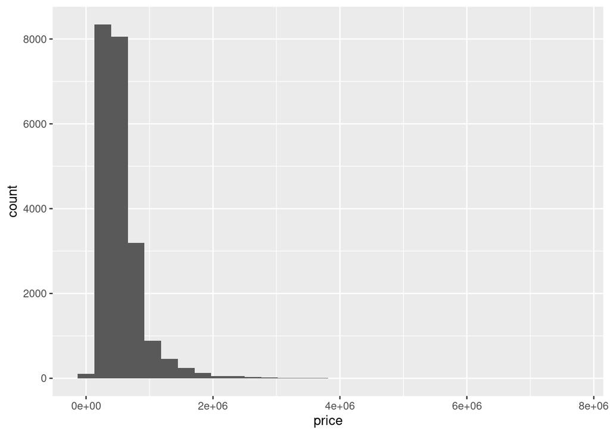

```r
# Histogram for price
ggplot(kc_house_data) +
  geom_histogram(aes(x=price))
```

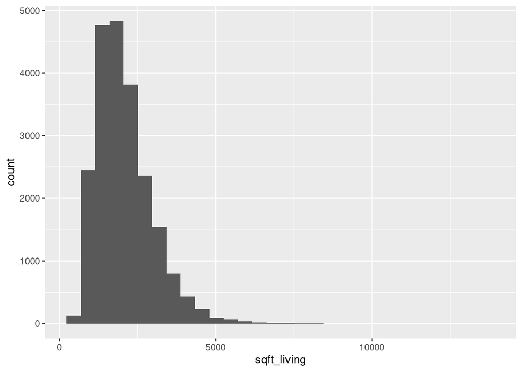

```r
#Histogram for sqft_living
ggplot(kc_house_data) +
  geom_histogram(aes(x=sqft_living))
```

Write a short paragraph describing the distribution of of these two variables.

> Both variables, price and sqft, have a right skewed distribution.

Repeat the histogram for `price` but make the following style changes to the plot.

- Add an approprate graph title
- Change y-axis label to “Number of houses”
- Change x-axis label to “Selling price”
- Change the colors of the bars to something other than the default

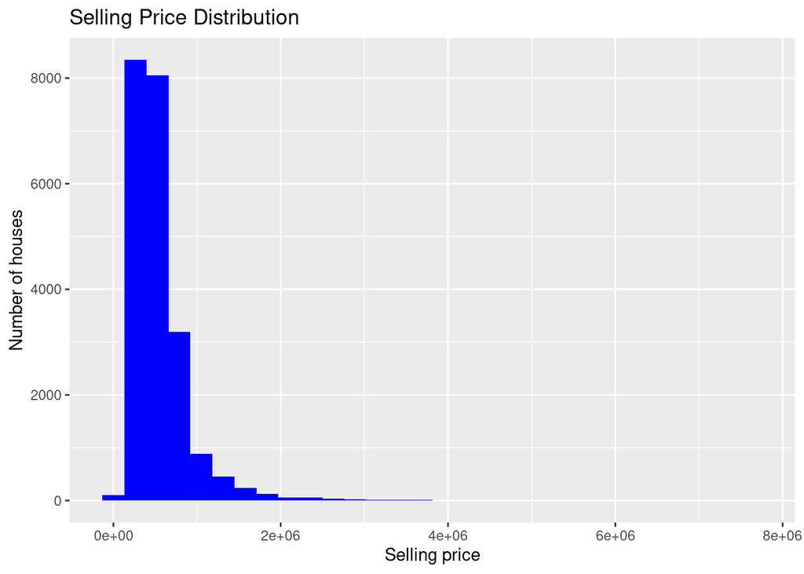

```r
# Histogram for price
ggplot(kc_house_data) +
  geom_histogram(aes(x=price), fill = "blue")+
    labs(title="Selling Price Distribution", x="Selling price", y="Number of houses")
```

Now create a set of histograms for `price` in which you facet by condition

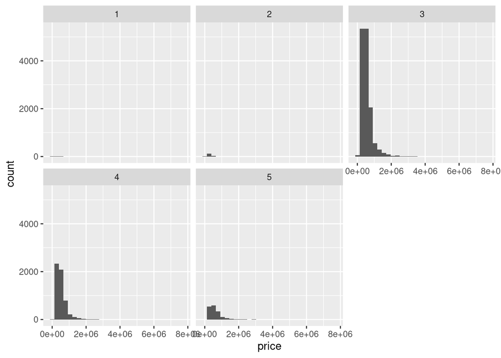

```r
ggplot(kc_house_data) +
  geom_histogram(aes(x=price)) +
  facet_wrap(~condition)
```

Since the number of houses varies by `condition`, create a new version of the plot above but modify so that the y-axis shows frequency percentages (or density values) instead of counts. Hint: See the [documentation](https://ggplot2.tidyverse.org/reference/geom_histogram.html)

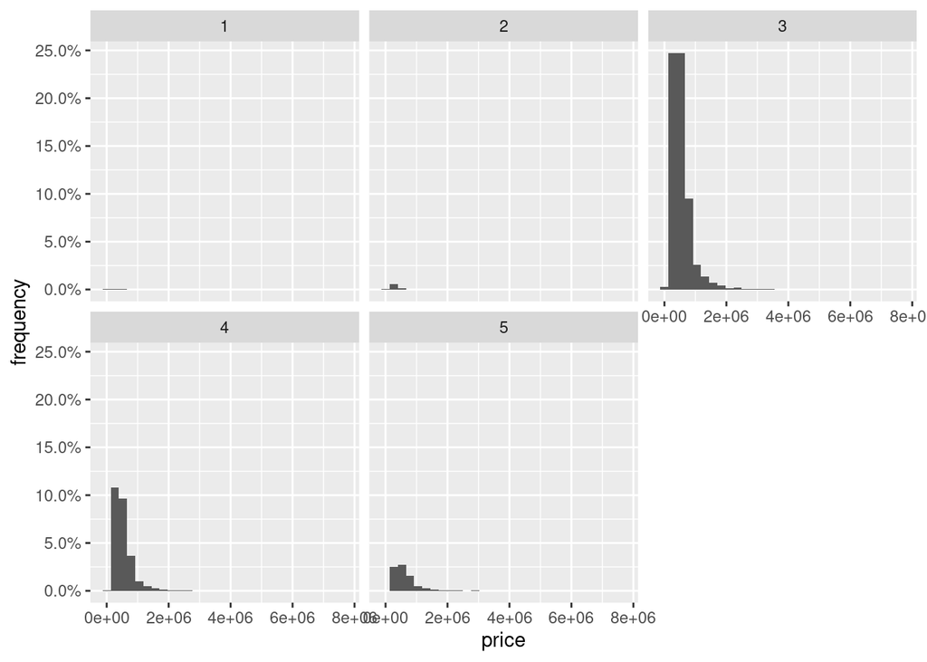

```r
ggplot(kc_house_data) +
  geom_histogram(aes(x=price, y=after_stat(count / sum(count)))) +
  scale_y_continuous(labels = scales::percent) +
  labs(y="frequency") +
  facet_wrap(~condition)
```

Now create boxplots and violin plots for the same two variables - `price` and `sqft_living`. However, you’ll see that for both of these plot types, ggplot wants an `x` aesthetic to act as a grouping variable. Use the `condition` field as your `x` aesthetic. Note anything of interest revealed by these plots.

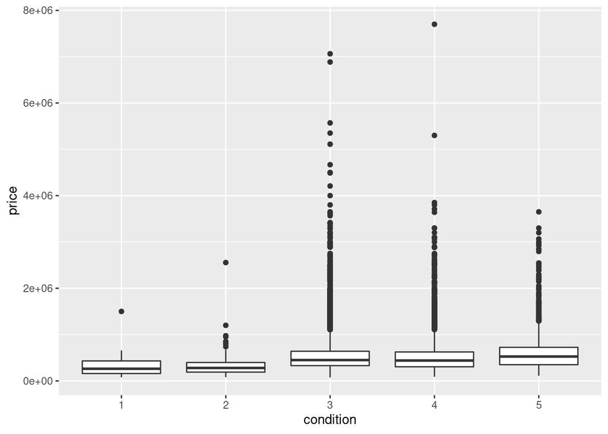

```r
# Boxplots and violin plots
ggplot(kc_house_data) +
  geom_boxplot(aes(x=condition, y=price))
```

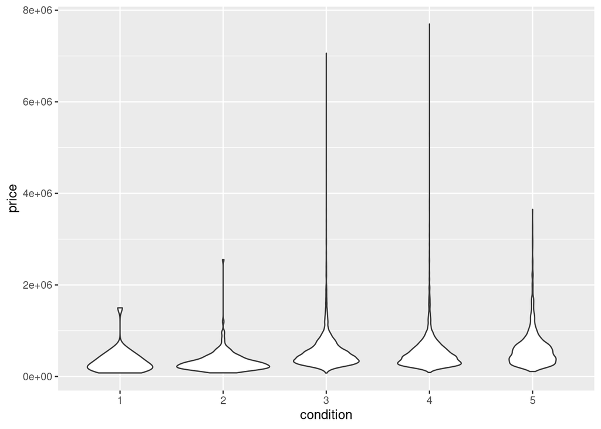

```r
ggplot(kc_house_data) +
  geom_violin(aes(x=condition, y=price))
```

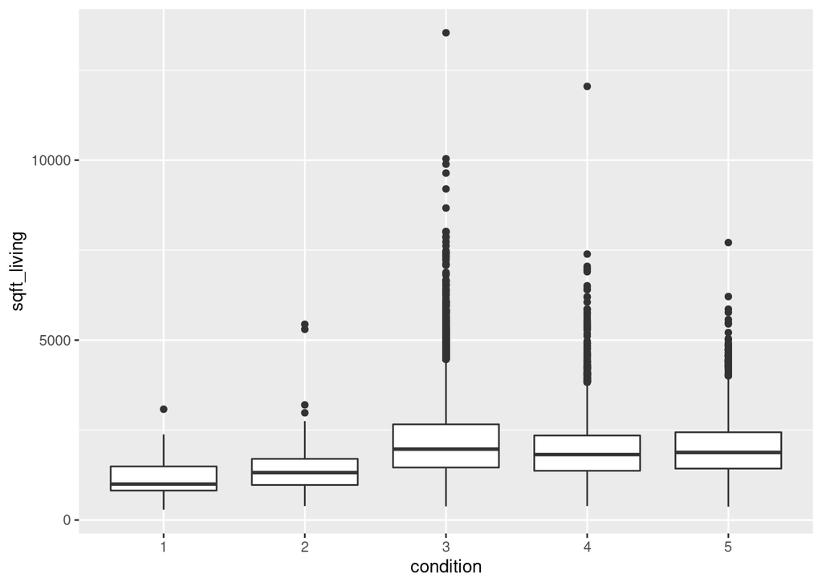

```r
ggplot(kc_house_data) +
  geom_boxplot(aes(x=condition, y=sqft_living))
```

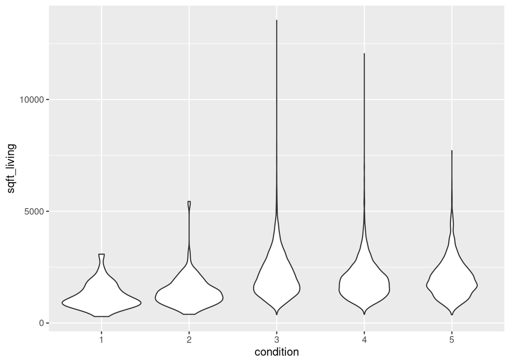

```r
ggplot(kc_house_data) +
  geom_violin(aes(x=condition, y=sqft_living))
```

> Box plots display specific statistical points like the median, range, IQR and outliers for house prices for the 5 conditions. In addition to the statistical points, the violin plot also displays the distribution of the data. For instance, the violin plots for house prices show a higher concentration of data (mode) below the IQR, displaying the skewness of the distribution.

Repeat the histogram of `sqft_living` but only for houses with a `condition` equal to 3. You can either use dplyr to do the filtering or boolean indexing (see intro to dataframes Rmd file).

**HACKER EXTRA:** In addition, overlay a kernel density plot on top of the histogram.

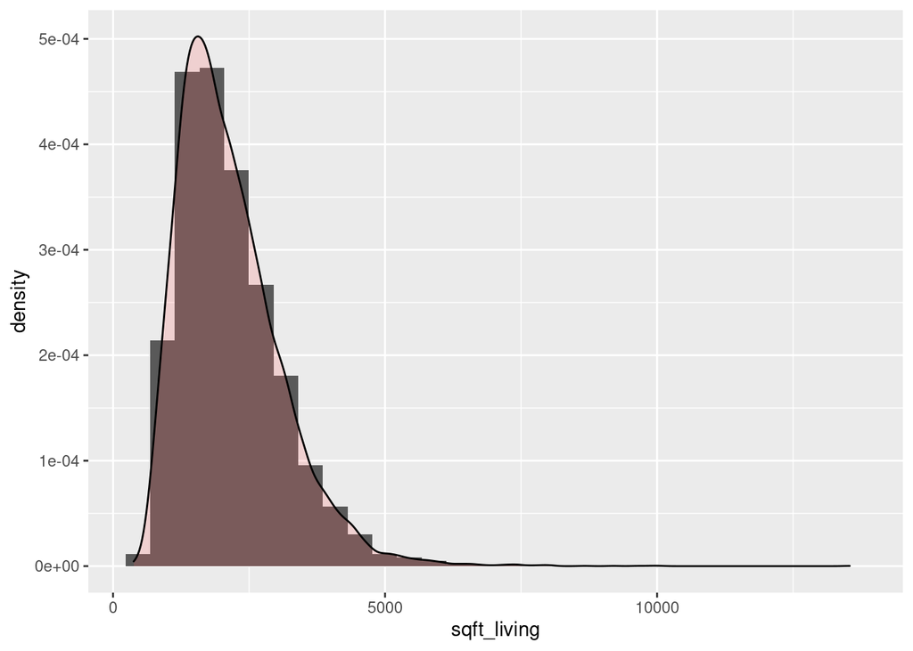

```r
kc_house_data_cond3 <- filter(kc_house_data, condition == 3)
  ggplot(kc_house_data_cond3, aes(x=sqft_living)) +
    geom_histogram(aes(y=..density..)) +
    geom_density(alpha=.2, fill="#FF6666")
```

Create boxplots and/or violin plots showing how prices compare with respect to the number of bedrooms.

Summarize your findings.

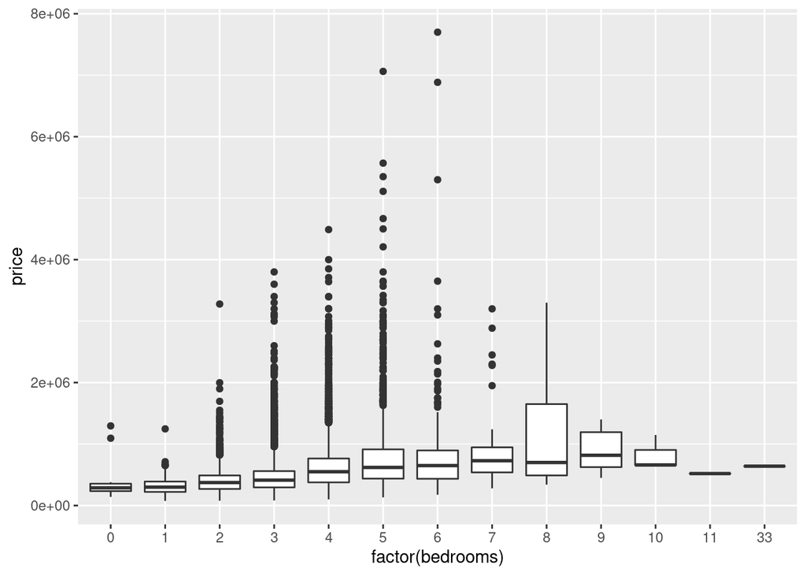

```r
ggplot(kc_house_data, aes(x=factor(bedrooms), y=price)) +
  geom_boxplot()
```

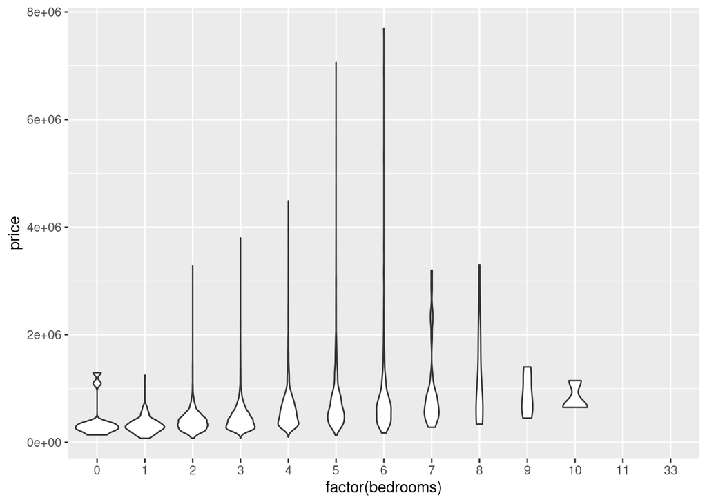

```r
ggplot(kc_house_data) +
  geom_violin(aes(x=factor(bedrooms), y=price))
```

> The plots indicate a right skewed distribution for price of houses with 2 to 5 bedrooms. This is more pronounced in the violin plot. For example, the violin plot reveals more of a bimodal distribution for the price of houses with 10 bedrooms which was not revealed by the box plot.

### Problem 3 - Basic bar chart

Create a bar chart showing the number of houses by grade.

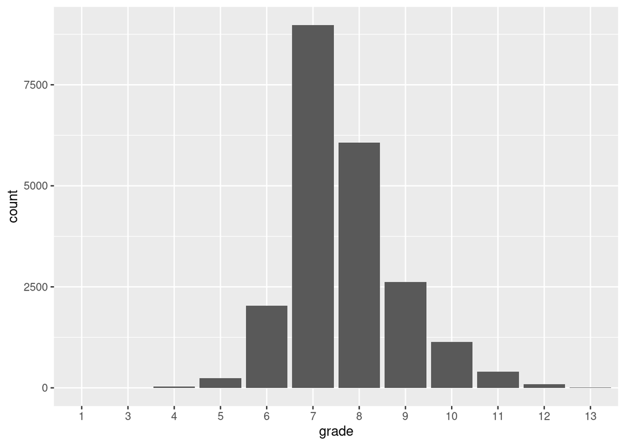

```r
ggplot(kc_house_data) + geom_bar(aes(x=grade))
```

### Problem 4 - Basic scatter plots

Create a scatter plot of prices vs sqft_living.

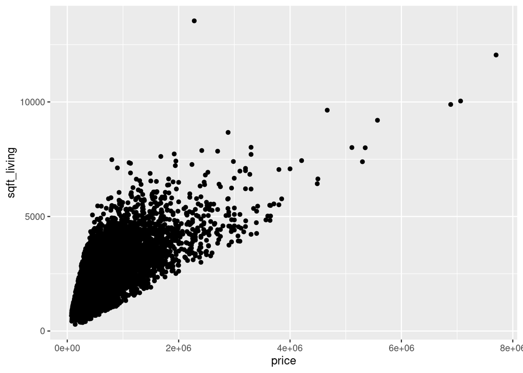

```r
ggplot(kc_house_data) +
  geom_point(aes(x=price, y=sqft_living))
```

Create a modified version of the above scatter plot in which:

- only houses less than 3000 square feet are included,
- the point color is mapped to condition

You could also facet by condition if you think that makes the plot easier to interpret.

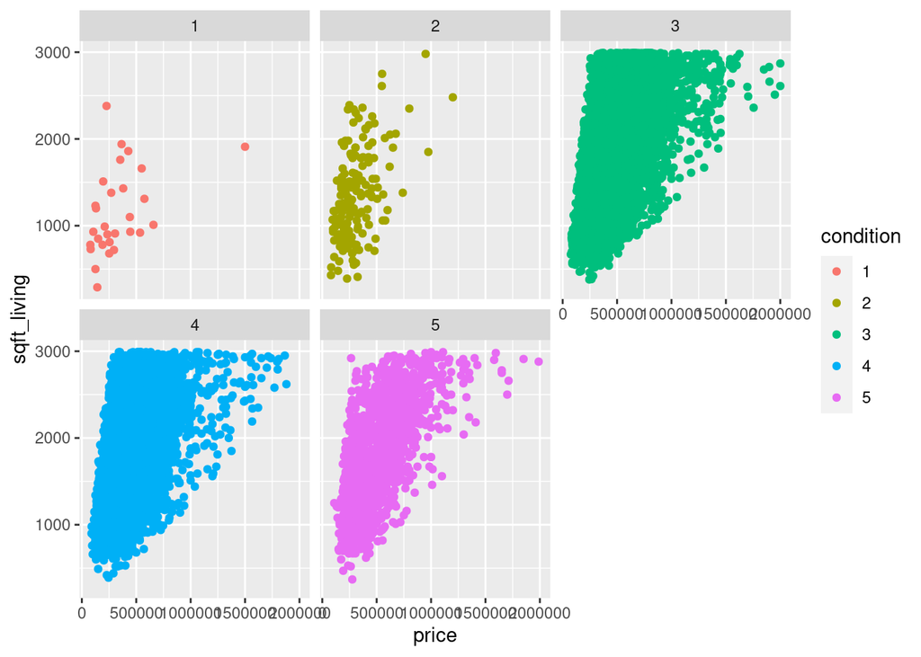

```r
kc_house_data_3000sqft <- filter(kc_house_data, sqft_living < 3000)
ggplot(kc_house_data_3000sqft) +
  geom_point(aes(x=price, y=sqft_living, colour=condition)) +
  facet_wrap(~condition)
```

> The scatter plot reveals a linear relationship between living space (sq_ft) and price

Make one more scatter plot involving `price` and `sqft_living`. But, figure out a way to either change the axis scales or the plotted data itself to use a base 10 logarithmic scale (or transform). Write a short paragraph on why one might want to use a log scale or log transform of data when plotting.

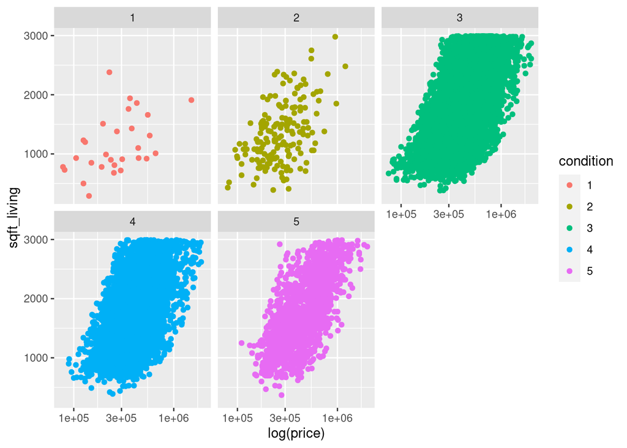

```r
kc_house_data_3000sqft <- filter(kc_house_data, sqft_living < 3000)
ggplot(kc_house_data_3000sqft) +
  geom_point(aes(x=price, y=sqft_living, colour=condition)) +
  xlab("log(price)") + scale_x_log10() +
  facet_wrap(~condition)
```

> Log scale helps depicts data with a wide range of values. In this instance, using a log scale increased the amount of data displayed for houses in condition 1 and 2.

### Problem 5 - correlations

Create a correlation matrix and a correlation plot (using corrplot library) which includes the following variables:

- price (col 3)
- bedrooms (col 4)
- bathrooms (col 5)
- sqft_living (col 6)
- sqft_lot (col 7)
- floors (col 8)
- sqft_above (col 13)
- sqft_basement (col 14)
- sqft_living15 (col 20)
- sqft_lot15 (col 21)
- age (col 22)

```r
cor_mat <- cor(kc_house_data[,c(3:8,13,14,20:22)])
cor_mat
```

```
##                     price    bedrooms   bathrooms sqft_living     sqft_lot
## price          1.00000000  0.30834960  0.52513751   0.7020351  0.089660861
## bedrooms       0.30834960  1.00000000  0.51588364   0.5766707  0.031703243
## bathrooms      0.52513751  0.51588364  1.00000000   0.7546653  0.087739662
## sqft_living    0.70203505  0.57667069  0.75466528   1.0000000  0.172825661
## sqft_lot       0.08966086  0.03170324  0.08773966   0.1728257  1.000000000
## floors         0.25679389  0.17542894  0.50065317   0.3539493 -0.005200991
## sqft_above     0.60556730  0.47760016  0.68534248   0.8765966  0.183512281
## sqft_basement  0.32381602  0.30309338  0.28377003   0.4350430  0.015286202
## sqft_living15  0.58537890  0.39163752  0.56863429   0.7564203  0.144608174
## sqft_lot15     0.08244715  0.02924422  0.08717536   0.1832856  0.718556752
## age           -0.05401153 -0.15417807 -0.50601944  -0.3180488 -0.053080367
##                     floors  sqft_above sqft_basement sqft_living15  sqft_lot15
## price          0.256793888  0.60556730    0.32381602     0.5853789  0.08244715
## bedrooms       0.175428935  0.47760016    0.30309338     0.3916375  0.02924422
## bathrooms      0.500653173  0.68534248    0.28377003     0.5686343  0.08717536
## sqft_living    0.353949290  0.87659660    0.43504297     0.7564203  0.18328555
## sqft_lot      -0.005200991  0.18351228    0.01528620     0.1446082  0.71855675
## floors         1.000000000  0.52388471   -0.24570454     0.2798853 -0.01126919
## sqft_above     0.523884710  1.00000000   -0.05194331     0.7318703  0.19404986
## sqft_basement -0.245704542 -0.05194331    1.00000000     0.2003550  0.01727618
## sqft_living15  0.279885265  0.73187029    0.20035498     1.0000000  0.18319175
## sqft_lot15    -0.011269187  0.19404986    0.01727618     0.1831917  1.00000000
## age           -0.489319425 -0.42389835    0.13312410    -0.3262289 -0.07095793
##                       age
## price         -0.05401153
## bedrooms      -0.15417807
## bathrooms     -0.50601944
## sqft_living   -0.31804877
## sqft_lot      -0.05308037
## floors        -0.48931942
## sqft_above    -0.42389835
## sqft_basement  0.13312410
## sqft_living15 -0.32622890
## sqft_lot15    -0.07095793
## age            1.00000000
```

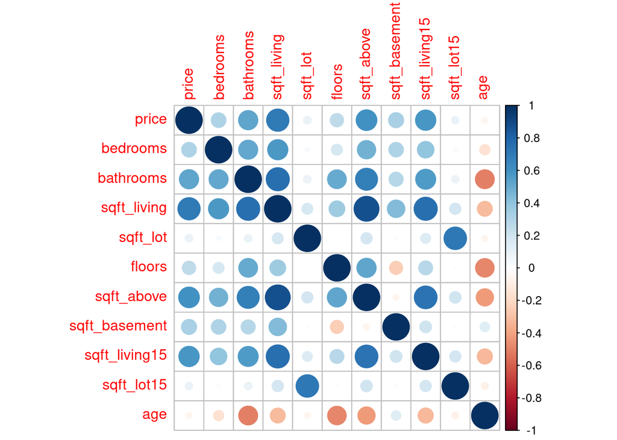

```r
library(corrplot)
corrplot(cor_mat, method="circle")
```

> The correlation plot shows a positive correlation between price and living space, and a negative correlation between age and living space (sqft, floors, bedrooms & bathrooms)

### Problem 6 - automated EDA

There are a number of packages that try to help automate the process of initial EDA of a dataframe. I want you to try out the skimr package. If the package isn’t already installed, just install it. Run the `skim()` function on `kc_house_data` and then write a few short paragraphs describing the types of outputs you get from skimr.

```r
# install.packages("skimr")
library(skimr)
```

```r
# Use skim() function on kc_house_data
  skim(kc_house_data)
```

Data summary

| Name | kc_house_data |
| --- | --- |
| Number of rows | 21613 |
| Number of columns | 23 |
| _______________________ |  |
| Column type frequency: |  |
| character | 1 |
| factor | 5 |
| numeric | 17 |
| ________________________ |  |
| Group variables | None |

**Variable type: character**

| skim_variable | n_missing | complete_rate | min | max | empty | n_unique | whitespace |
| --- | --- | --- | --- | --- | --- | --- | --- |
| date | 0 | 1 | 15 | 15 | 0 | 372 | 0 |

**Variable type: factor**

| skim_variable | n_missing | complete_rate | ordered | n_unique | top_counts |
| --- | --- | --- | --- | --- | --- |
| waterfront | 0 | 1 | FALSE | 2 | 0: 21450, 1: 163 |
| view | 0 | 1 | FALSE | 5 | 0: 19489, 2: 963, 3: 510, 1: 332 |
| condition | 0 | 1 | FALSE | 5 | 3: 14031, 4: 5679, 5: 1701, 2: 172 |
| grade | 0 | 1 | FALSE | 12 | 7: 8981, 8: 6068, 9: 2615, 6: 2038 |
| zipcode | 0 | 1 | FALSE | 70 | 981: 602, 980: 590, 981: 583, 980: 574 |

**Variable type: numeric**

| skim_variable | n_missing | complete_rate | mean | sd | p0 | p25 | p50 | p75 | p100 | hist |
| --- | --- | --- | --- | --- | --- | --- | --- | --- | --- | --- |
| id | 0 | 1 | 4580301520.86 | 2.876566e+09 | 1000102.00 | 2123049194.00 | 3.90493e+09 | 7.3089e+09 | 9900000190.00 | ▇▇▃▆▅ |
| price | 0 | 1 | 540088.14 | 3.671272e+05 | 75000.00 | 321950.00 | 4.50000e+05 | 6.4500e+05 | 7700000.00 | ▇▁▁▁▁ |
| bedrooms | 0 | 1 | 3.37 | 9.300000e-01 | 0.00 | 3.00 | 3.00000e+00 | 4.0000e+00 | 33.00 | ▇▁▁▁▁ |
| bathrooms | 0 | 1 | 2.11 | 7.700000e-01 | 0.00 | 1.75 | 2.25000e+00 | 2.5000e+00 | 8.00 | ▃▇▁▁▁ |
| sqft_living | 0 | 1 | 2079.90 | 9.184400e+02 | 290.00 | 1427.00 | 1.91000e+03 | 2.5500e+03 | 13540.00 | ▇▂▁▁▁ |
| sqft_lot | 0 | 1 | 15106.97 | 4.142051e+04 | 520.00 | 5040.00 | 7.61800e+03 | 1.0688e+04 | 1651359.00 | ▇▁▁▁▁ |
| floors | 0 | 1 | 1.49 | 5.400000e-01 | 1.00 | 1.00 | 1.50000e+00 | 2.0000e+00 | 3.50 | ▇▅▁▁▁ |
| sqft_above | 0 | 1 | 1788.39 | 8.280900e+02 | 290.00 | 1190.00 | 1.56000e+03 | 2.2100e+03 | 9410.00 | ▇▃▁▁▁ |
| sqft_basement | 0 | 1 | 291.51 | 4.425800e+02 | 0.00 | 0.00 | 0.00000e+00 | 5.6000e+02 | 4820.00 | ▇▁▁▁▁ |
| yr_built | 0 | 1 | 1971.01 | 2.937000e+01 | 1900.00 | 1951.00 | 1.97500e+03 | 1.9970e+03 | 2015.00 | ▂▃▇▇▇ |
| yr_renovated | 0 | 1 | 84.40 | 4.016800e+02 | 0.00 | 0.00 | 0.00000e+00 | 0.0000e+00 | 2015.00 | ▇▁▁▁▁ |
| lat | 0 | 1 | 47.56 | 1.400000e-01 | 47.16 | 47.47 | 4.75700e+01 | 4.7680e+01 | 47.78 | ▁▃▅▇▇ |
| long | 0 | 1 | -122.21 | 1.400000e-01 | -122.52 | -122.33 | -1.22230e+02 | -1.2212e+02 | -121.32 | ▇▇▂▁▁ |
| sqft_living15 | 0 | 1 | 1986.55 | 6.853900e+02 | 399.00 | 1490.00 | 1.84000e+03 | 2.3600e+03 | 6210.00 | ▅▇▂▁▁ |
| sqft_lot15 | 0 | 1 | 12768.46 | 2.730418e+04 | 651.00 | 5100.00 | 7.62000e+03 | 1.0083e+04 | 871200.00 | ▇▁▁▁▁ |
| age | 0 | 1 | 43.99 | 2.937000e+01 | 0.00 | 18.00 | 4.00000e+01 | 6.4000e+01 | 115.00 | ▇▇▇▃▂ |
| reno_age | 0 | 1 | 41.61 | 2.881000e+01 | 0.00 | 16.00 | 3.80000e+01 | 6.1000e+01 | 115.00 | ▇▆▆▂▂ |

> Skimmer summarizes, compacts and presents statistical data of an object. It provides information on the structure of the dataframe or object. It provides statistical values for each property (column in the dataframe), and displays the distrubtion of the data for each property in the form of a histogram. All of which are structured and presented in a table

## Deliverables for this problem

Make sure you knit your Rmd file. IMPORTANT: You might notice that there’s a file with the same base name as your file and with a .nb.html extension. The “nb” stands for “notebook” and that file is created on the fly as you are working in your notebook. DO NOT SUBMIT THAT FILE. YOU MUST DO A “knit to html” from the toolbar which will generate a file with just the .html extension. As discussed earlier, if you have errors, your document won’t knit. Comment out error lines and put a comment in saying that you couldn’t get the code chunk to work. After your file is knitted into an html file, simply create a compressed archive (either tar.gz or .zip) of your project folder and upload the compressed archive file into Moodle.